# K27ac_SAPnorm_LmCTCFpeaks_June20

```r
#9. Keep only the entries were both replicates have reads
    badgenes_0h = which(rowSums(res_0h_br1)<10 | rowSums(res_0h_br2)<10 | rowSums(res_1h_br1)<10 | rowSums(res_1h_br2)<10 | rowSums(res_4h_br1)<10 | rowSums(res_4h_br2)<10);
    filtered_0h_br1 = res_0h_br1[-badgenes_0h,];
    filtered_0h_br2 = res_0h_br2[-badgenes_0h,];

    #1h
    filtered_1h_br1 = res_1h_br1[-badgenes_0h,];
    filtered_1h_br2 = res_1h_br2[-badgenes_0h,];

    #4h
    filtered_4h_br1 = res_4h_br1[-badgenes_0h,];
    filtered_4h_br2 = res_4h_br2[-badgenes_0h,];
```

```r
#9. Subsample residual matrices and plot metaplots
    res_0h_br1.subs = metaSubsampleMatrix(filtered_0h_br1  /3002);
    res_1h_br1.subs = metaSubsampleMatrix(filtered_1h_br1  /9218);
    res_4h_br1.subs = metaSubsampleMatrix(filtered_4h_br1  /8084);

    res_0h_br2.subs = metaSubsampleMatrix(filtered_0h_br2  /1042 * 0.639274463601264);
    res_1h_br2.subs = metaSubsampleMatrix(filtered_1h_br2  /7368 * 0.639274463601264);
    res_4h_br2.subs = metaSubsampleMatrix(filtered_4h_br2  /7984 * 0.639274463601264);
```

```r
#10. Give miningful names to each dataset --> thse names will be used as labels for the plot
    res_0h_br1.subs$sample.name = "0h Rep1";
    res_1h_br1.subs$sample.name = "1h Rep1";
    res_4h_br1.subs$sample.name = "4h Rep1";

    res_0h_br2.subs$sample.name = "0h Rep2";
    res_1h_br2.subs$sample.name = "1h Rep2";
    res_4h_br2.subs$sample.name = "4h Rep2";
```

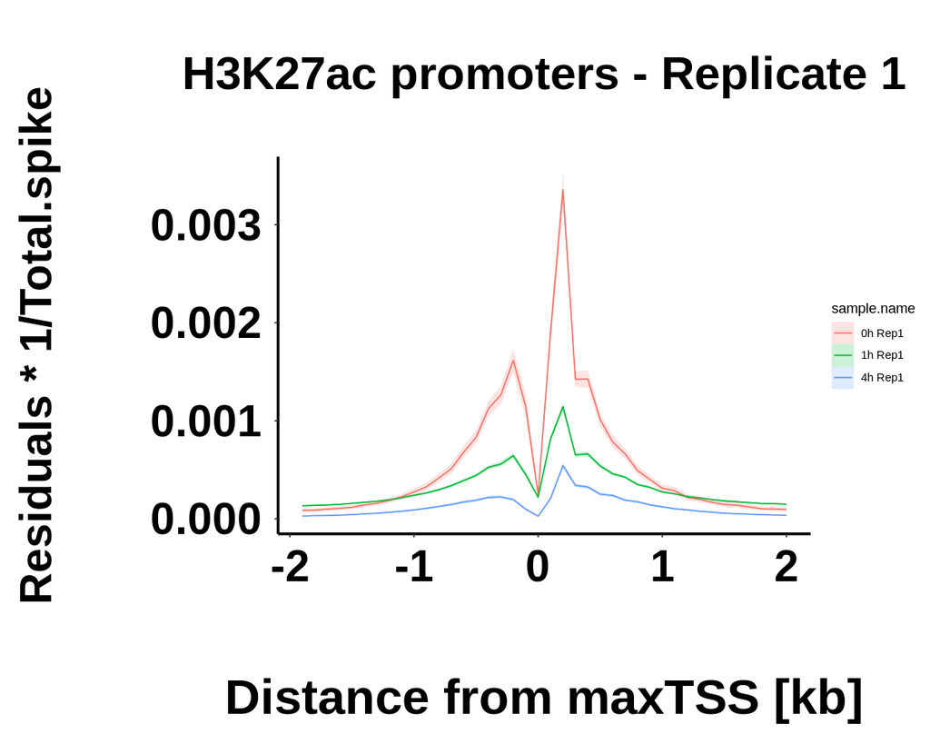

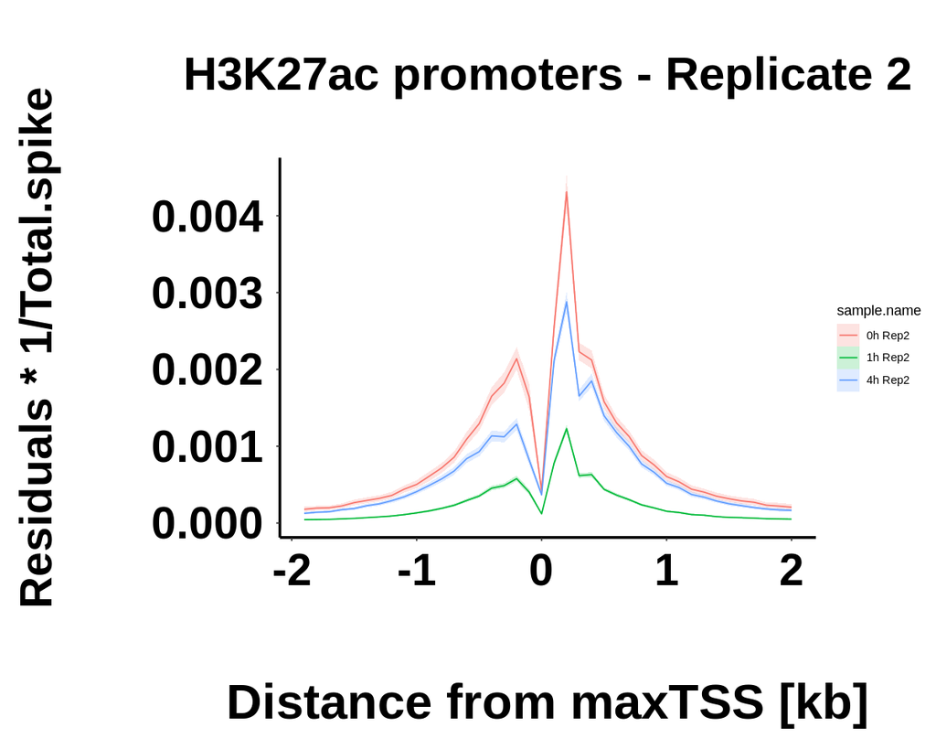

```r
#11. The actual plotting
### V. Make mataplots to make sure the different normalization strategies produce the same metaprofiles ---> RPM norm data
    options(jupyter.plot_mimetypes="image/png", repr.plot.width=10, repr.plot.height=8);

plot_BR1.RPM = rbind(res_0h_br1.subs, res_1h_br1.subs, res_4h_br1.subs);

        ggplot(plot_BR1.RPM, aes(x=x, y=mean, color=sample.name)) +
        geom_line() +
        geom_ribbon( aes( ymin=lower, ymax=upper, fill=sample.name ), alpha=0.2, size=0 ) +
        #scale_y_continuous(limits = c(0, 0.020), breaks=c(0, 0.003, 0.005)) +
        scale_x_continuous(labels = c(-2, -1, 0, 1, 2), breaks=c(0, 10, 20, 30, 40)) +
        labs(
            title = "\n H3K27ac promoters - Replicate 1 \n ",
            x = "Distance from maxTSS [kb]",
            y = "Residuals * 1/Total.spike"
        ) +
        theme_classic() +
        theme(
            panel.border = element_blank(),
            # Remove panel background
            panel.background = element_blank(),
            legend.background = element_blank(),
            # Add axis line
            axis.line = element_line(colour = "black", size=1),
            panel.grid.major = element_line(colour = "white"),
            plot.title = element_text(color="black", size=36, face="bold", hjust = 0.5),
            axis.text.x = element_text(face="bold", color="black", size=34, margin=margin(t = 10, r = 0, b = 20, l = 0)),
            axis.text.y = element_text(face="bold", color="black", size=34, margin=margin(t = 0, r = 10, b = 0, l = 50)),
            axis.title.x = element_text(color="black", size=38, face="bold", margin = margin(t = 50, r = 0, b = 10, l = 0)),
            axis.title.y = element_text(color="black", size=34, face="bold", margin = margin(t = 0, r = 20, b = 0, l = 10))
        )



plot_BR2.RPM = rbind(res_0h_br2.subs, res_1h_br2.subs, res_4h_br2.subs);

        ggplot(plot_BR2.RPM, aes(x=x, y=mean, color=sample.name)) +
        geom_line() +
        geom_ribbon( aes( ymin=lower, ymax=upper, fill=sample.name ), alpha=0.2, size=0 ) +
        #scale_y_continuous(limits = c(0, 0.020), breaks=c(0, 0.008, 0.012, 0.016)) +
        scale_x_continuous(labels = c(-2, -1, 0, 1, 2), breaks=c(0, 10, 20, 30, 40)) +
        labs(
            title = "\n H3K27ac promoters - Replicate 2 \n ",
            x = "Distance from maxTSS [kb]",
            y = "Residuals * 1/Total.spike"
        ) +
        theme_classic() +
        theme(
            panel.border = element_blank(),
            # Remove panel background
            panel.background = element_blank(),
            legend.background = element_blank(),
            # Add axis line
            axis.line = element_line(colour = "black", size=1),
            panel.grid.major = element_line(colour = "white"),
            plot.title = element_text(color="black", size=36, face="bold", hjust = 0.5),
            axis.text.x = element_text(face="bold", color="black", size=34, margin=margin(t = 10, r = 0, b = 20, l = 0)),
            axis.text.y = element_text(face="bold", color="black", size=34, margin=margin(t = 0, r = 10, b = 0, l = 50)),
            axis.title.x = element_text(color="black", size=38, face="bold", margin = margin(t = 50, r = 0, b = 10, l = 0)),
            axis.title.y = element_text(color="black", size=34, face="bold", margin = margin(t = 0, r = 20, b = 0, l = 10))
        )
```

```r
sum(res_0h_br1.subs$mean)/sum(res_0h_br2.subs$mean)
```

0.639274463601264

# Compare replicates

#### Correlations between repliates will be determined by coputing a K-S test and by making scatter plots using data from the same time points in both biological replicates.

#### Good correlation between replicates will be indicated by a D ~ 0 (in the K-S test), and by data points in scatter plot aproaching the x=y diagonal.

#### A violin plot with very similar, if not the same, mean values in both replicates can be an alternative for the scatter plot.

```r
#Remove top and bottom 2.5% of data for K-S tests
rSums_0h_br1 = rowSums(filtered_0h_br1)/3002;
rSums_1h_br1 = rowSums(filtered_1h_br1)/9218;
rSums_4h_br1 = rowSums(filtered_4h_br1)/8084;


rSums_0h_br2 = rowSums(filtered_0h_br2)/1042 * 0.674982854348873;
rSums_1h_br2 = rowSums(filtered_1h_br2)/7368 * 0.674982854348873;
rSums_4h_br2 = rowSums(filtered_4h_br2)/7984 * 0.674982854348873;
```

```r
#Left merge the 2 peaks (knowing that they have the same peak.name column, in the same order)
            # 0h
                mark_0h = cbind((rSums_0h_br1), (rSums_0h_br2));
                colnames(mark_0h) = c("Rep1", "Rep2");
            # 1h
                mark_1h = cbind((rSums_1h_br1), (rSums_1h_br2));
                colnames(mark_1h) = c("Rep1", "Rep2");
            # 4h
                mark_4h = cbind((rSums_4h_br1), (rSums_4h_br2));
                colnames(mark_4h) = c("Rep1", "Rep2");
```

```r
### VII. Plot and correlate 0h datasets

#For correlations can also use:
cor.test(mark_0h[, "Rep1"], mark_0h[, "Rep2"], method = "pearson");
cor.test(mark_0h[, "Rep1"], mark_0h[, "Rep2"], method = "spearman");
```

```
	Pearson's product-moment correlation

data:  mark_0h[, "Rep1"] and mark_0h[, "Rep2"]
t = 268.25, df = 8367, p-value < 2.2e-16
alternative hypothesis: true correlation is not equal to 0
95 percent confidence interval:
 0.9442067 0.9486721
sample estimates:
      cor
0.9464846
```

```
	Spearman's rank correlation rho

data:  mark_0h[, "Rep1"] and mark_0h[, "Rep2"]
S = 1.0289e+10, p-value < 2.2e-16
alternative hypothesis: true rho is not equal to 0
sample estimates:
      rho
0.8946809
```

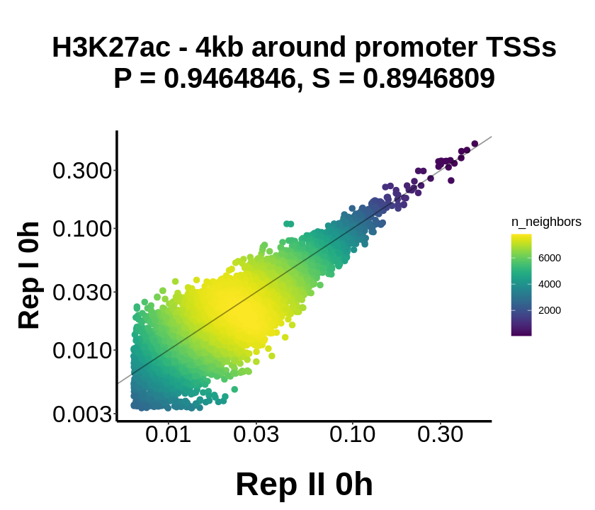

```r
options(warn=-1)


options(jupyter.plot_mimetypes="image/png", repr.plot.width=7, repr.plot.height=6);

ggplot(as.data.frame(mark_0h), mapping=aes(Rep2, Rep1)) + geom_point() +
    #The distance threshold to consider two points as neighbors (smoothing bandwidth) can be adjusted with the adjust argument,
    #where adjust = 0.5 means use half of the default bandwidth.
    geom_pointdensity(adjust = 10, size = 2) +
    scale_color_viridis()+
    geom_abline(alpha=0.4) +
    scale_x_log10() + scale_y_log10() +
    labs(
        title = "\n H3K27ac - 4kb around promoter TSSs \n P = 0.9464846, S = 0.8946809 \n",
        x = "Rep II 0h",
        y = "Rep I 0h"
    ) +
    theme_classic() +
    theme(
        #panel.border = element_blank(),
        # Remove panel background
        panel.background = element_blank(),
        legend.background = element_blank(),
        # Add axis line
        axis.line = element_line(colour = "black", size=1),
        panel.grid.major = element_line(colour = "white"),
        plot.title = element_text(color="black", size=24, face="bold", hjust = 0.5),
        axis.text.x = element_text( color="black", size=20, margin=margin(t = 1, r = 0, b = 2, l = 0)),
        axis.text.y = element_text( color="black", size=20, margin=margin(t = 0, r = 1, b = 0, l = 5)),
        axis.title.x = element_text(color="black", size=28, face="bold", margin = margin(t = 20, r = 0, b = 1, l = 0)),
        axis.title.y = element_text(color="black", size=24, face="bold", margin = margin(t = 0, r = 2, b = 0, l = 10))
    )
```

```r
### VII. Plot and correlate 0h datasets

#For correlations can also use:
cor.test(mark_1h[, "Rep1"], mark_1h[, "Rep2"], method = "pearson");
cor.test(mark_1h[, "Rep1"], mark_1h[, "Rep2"], method = "spearman");
```

```
	Pearson's product-moment correlation

data:  mark_1h[, "Rep1"] and mark_1h[, "Rep2"]
t = 281.79, df = 8367, p-value < 2.2e-16
alternative hypothesis: true correlation is not equal to 0
95 percent confidence interval:
 0.9490595 0.9531459
sample estimates:
      cor
0.9511444
```

```
	Spearman's rank correlation rho

data:  mark_1h[, "Rep1"] and mark_1h[, "Rep2"]
S = 8.213e+09, p-value < 2.2e-16
alternative hypothesis: true rho is not equal to 0
sample estimates:
      rho
0.9159316
```

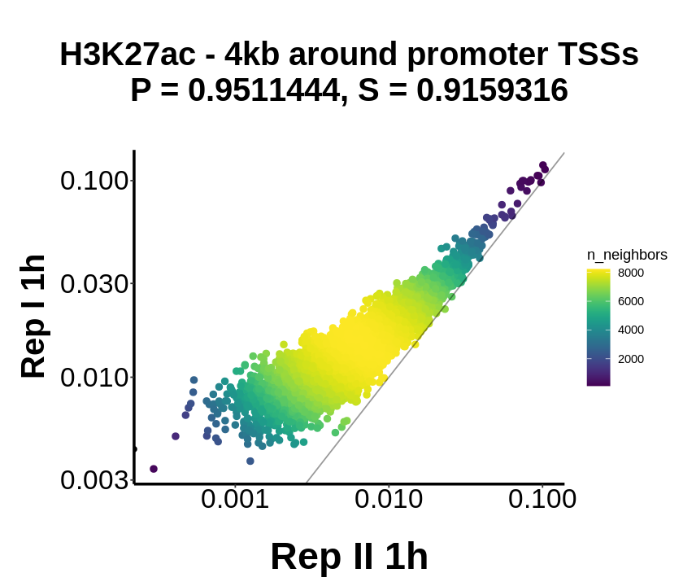

```r
options(warn=-1)


options(jupyter.plot_mimetypes="image/png", repr.plot.width=7, repr.plot.height=6);

ggplot(as.data.frame(mark_1h), mapping=aes(Rep2, Rep1)) + geom_point() +
    #The distance threshold to consider two points as neighbors (smoothing bandwidth) can be adjusted with the adjust argument,
    #where adjust = 0.5 means use half of the default bandwidth.
    geom_pointdensity(adjust = 10, size = 2) +
    scale_color_viridis()+
    geom_abline(alpha=0.4) +
    scale_x_log10() + scale_y_log10() +
    labs(
        title = "\n H3K27ac - 4kb around promoter TSSs \n P = 0.9511444, S = 0.9159316 \n",
        x = "Rep II 1h",
        y = "Rep I 1h"
    ) +
    theme_classic() +
    theme(
        #panel.border = element_blank(),
        # Remove panel background
        panel.background = element_blank(),
        legend.background = element_blank(),
        # Add axis line
        axis.line = element_line(colour = "black", size=1),
        panel.grid.major = element_line(colour = "white"),
        plot.title = element_text(color="black", size=24, face="bold", hjust = 0.5),
        axis.text.x = element_text( color="black", size=20, margin=margin(t = 1, r = 0, b = 2, l = 0)),
        axis.text.y = element_text( color="black", size=20, margin=margin(t = 0, r = 1, b = 0, l = 5)),
        axis.title.x = element_text(color="black", size=28, face="bold", margin = margin(t = 20, r = 0, b = 1, l = 0)),
        axis.title.y = element_text(color="black", size=24, face="bold", margin = margin(t = 0, r = 2, b = 0, l = 10))
    )
```

```r
### VII. Plot and correlate 0h datasets

#For correlations can also use:
cor.test(mark_4h[, "Rep1"], mark_4h[, "Rep2"], method = "pearson");
cor.test(mark_4h[, "Rep1"], mark_4h[, "Rep2"], method = "spearman");
```

```
	Pearson's product-moment correlation

data:  mark_4h[, "Rep1"] and mark_4h[, "Rep2"]
t = 176.05, df = 8367, p-value < 2.2e-16
alternative hypothesis: true correlation is not equal to 0
95 percent confidence interval:
 0.8827296 0.8918416
sample estimates:
      cor
0.8873722
```

```
	Spearman's rank correlation rho

data:  mark_4h[, "Rep1"] and mark_4h[, "Rep2"]
S = 1.3407e+10, p-value < 2.2e-16
alternative hypothesis: true rho is not equal to 0
sample estimates:
      rho
0.8627682
```

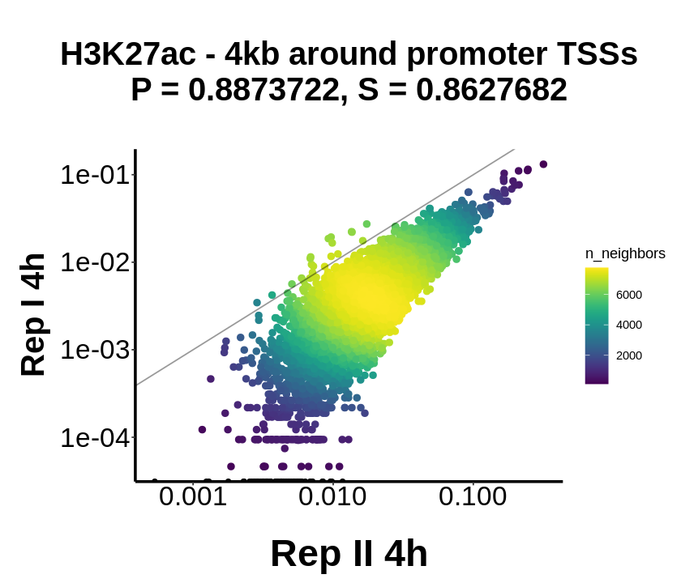

```r
options(warn=-1)


options(jupyter.plot_mimetypes="image/png", repr.plot.width=7, repr.plot.height=6);

ggplot(as.data.frame(mark_4h), mapping=aes(Rep2, Rep1)) + geom_point() +
    #The distance threshold to consider two points as neighbors (smoothing bandwidth) can be adjusted with the adjust argument,
    #where adjust = 0.5 means use half of the default bandwidth.
    geom_pointdensity(adjust = 10, size = 2) +
    scale_color_viridis()+
    geom_abline(alpha=0.4) +
    scale_x_log10() + scale_y_log10() +
    labs(
        title = "\n H3K27ac - 4kb around promoter TSSs \n P = 0.8873722, S = 0.8627682 \n",
        x = "Rep II 4h",
        y = "Rep I 4h"
    ) +
    theme_classic() +
    theme(
        #panel.border = element_blank(),
        # Remove panel background
        panel.background = element_blank(),
        legend.background = element_blank(),
        # Add axis line
        axis.line = element_line(colour = "black", size=1),
        panel.grid.major = element_line(colour = "white"),
        plot.title = element_text(color="black", size=24, face="bold", hjust = 0.5),
        axis.text.x = element_text( color="black", size=20, margin=margin(t = 1, r = 0, b = 2, l = 0)),
        axis.text.y = element_text( color="black", size=20, margin=margin(t = 0, r = 1, b = 0, l = 5)),
        axis.title.x = element_text(color="black", size=28, face="bold", margin = margin(t = 20, r = 0, b = 1, l = 0)),
        axis.title.y = element_text(color="black", size=24, face="bold", margin = margin(t = 0, r = 2, b = 0, l = 10))
    )
```

# Computing K-S test between replicates

```r
ks.test(mark_0h[, "Rep1"], mark_0h[, "Rep2"]);
```

```
	Two-sample Kolmogorov-Smirnov test

data:  mark_0h[, "Rep1"] and mark_0h[, "Rep2"]
D = 0.053172, p-value = 1.059e-10
alternative hypothesis: two-sided
```

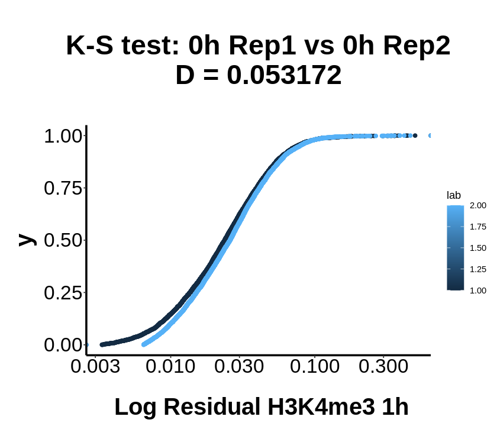

```r
#Plot the samples together
x = append(mark_0h[, "Rep1"], mark_0h[, "Rep2"]);
  lab = gl(2, length(mark_0h[, "Rep1"]), labels = c("0h_br1", "0h_br2"));


ggplot(as.data.frame(cbind(x, lab)), aes(x=as.numeric(x), group = as.numeric(lab), col=lab)) + stat_ecdf(geom = "point") +
    scale_x_log10() +
    labs(
            title = "\n K-S test: 0h Rep1 vs 0h Rep2 \n D = 0.053172 \n",
            x = " Log Residual H3K4me3 1h"
        ) +
        theme_classic() +
        theme(
            #panel.border = element_blank(),
            # Remove panel background
            panel.background = element_blank(),
            legend.background = element_blank(),
            # Add axis line
            axis.line = element_line(colour = "black", size=1),
            panel.grid.major = element_line(colour = "white"),
            plot.title = element_text(color="black", size=28, face="bold", hjust = 0.5),
            axis.text.x = element_text( color="black", size=20, margin=margin(t = 1, r = 0, b = 2, l = 0)),
            axis.text.y = element_text( color="black", size=20, margin=margin(t = 0, r = 1, b = 0, l = 5)),
            axis.title.x = element_text(color="black", size=24, face="bold", margin = margin(t = 20, r = 0, b = 1, l = 0)),
            axis.title.y = element_text(color="black", size=24, face="bold", margin = margin(t = 0, r = 2, b = 0, l = 10))
        )
```

## XI. `Draw Violin plots to show the distribution of normalized H3K27ac signal within peaks`

```r
library(tidyverse)
mark_violin = tibble(
    R1_0h=mark_0h[, "Rep1"],
    R2_0h=mark_0h[, "Rep2"],
    R1_1h=mark_1h[, "Rep1"],
    R2_1h=mark_1h[, "Rep2"],
    R1_4h=mark_4h[, "Rep1"],
    R2_4h=mark_4h[, "Rep2"],
    ID = 1:length(R1_0h)
) %>%
pivot_longer( R1_0h:R2_4h, names_to = "Sample", values_to = "Signal" ) %>%
#substr = select from column "Sample" at start=2, end=2
mutate( Rep=substr(Sample, 2, 2), time=substr(Sample, 4, 5) );
```

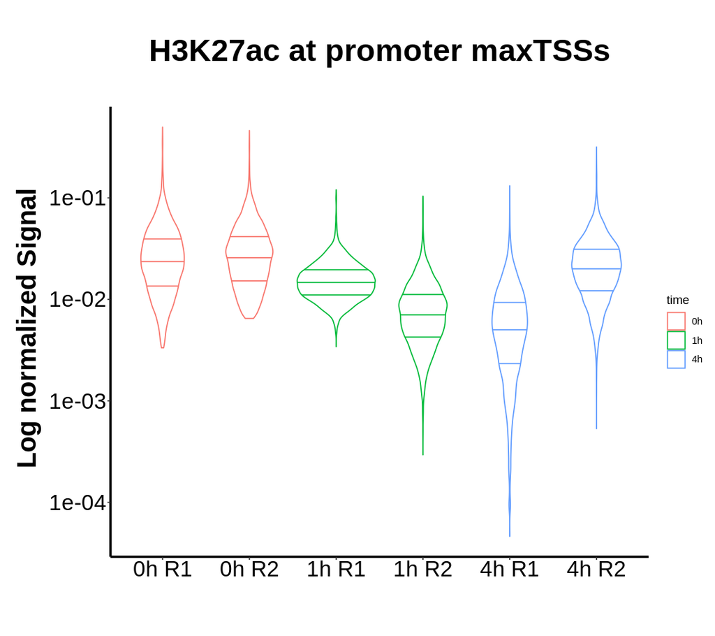

```r
options(jupyter.plot_mimetypes="image/png", repr.plot.width=9, repr.plot.height=8);


theme_set(
    theme_classic() +
    theme(
        #panel.border = element_blank(),
        # Remove panel background
        panel.background = element_blank(),
        legend.background = element_blank(),
        # Add axis line
        axis.line = element_line(colour = "black", size=1),
        panel.grid.major = element_line(colour = "white"),
        plot.title = element_text(color="black", size=28, face="bold", hjust = 0.5),
        axis.text.x = element_text( color="black", size=20, margin=margin(t = 1, r = 0, b = 2, l = 0)),
        axis.text.y = element_text( color="black", size=20, margin=margin(t = 0, r = 1, b = 0, l = 5)),
        axis.title.x = element_text(color="black", size=24, face="bold", margin = margin(t = 20, r = 0, b = 1, l = 0)),
        axis.title.y = element_text(color="black", size=24, face="bold", margin = margin(t = 0, r = 2, b = 0, l = 10))
    )
);

ggplot(mark_violin, aes(x=paste0(time, " R", Rep), y=as.numeric(Signal), col=time)) +
        geom_violin(draw_quantiles = c(0.25, 0.5, 0.75), alpha=0.5) +
        scale_y_log10() +
        labs(
            title = "\n H3K27ac at promoter maxTSSs \n",
            x = "",
            y = " Log normalized Signal"
        ) +
        scale_x_discrete() +
        scale_color_discrete()
```

## XII. `Draw PCA for normalized H3K27ac signal within peaks`

```r
#1. Merge all signals per peaks into one signle matrix
    mark_PCA = cbind(     as.numeric(mark_0h[, "Rep1"]), as.numeric(mark_1h[, "Rep1"]),
                          as.numeric(mark_4h[, "Rep1"]), as.numeric(mark_0h[, "Rep2"]),
                          as.numeric(mark_1h[, "Rep2"]), as.numeric(mark_4h[, "Rep2"]));
    colnames(mark_PCA) = c("H3K4me3 0h BR1", "H3K4me3 1h BR1", "H3K4me3 4h BR1", "H3K27H3K4me3c 0h BR2", "H3K4me3 1h BR2", "H3K4me3 4h BR2");

    #If any, replace all NAs with 0
    mark_PCA[is.na(mark_PCA)] = 0;

    head(mark_PCA)
```

A matrix: 6 × 6 of type dbl

[output not shown]

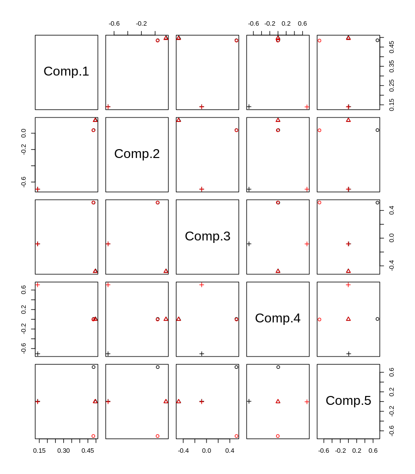

```r
#Make PCA:
options(jupyter.plot_mimetypes="image/png", repr.plot.width=7, repr.plot.height=8);

cols <-  rep(1:2, each=3);
pch <- c(rep(c(1:3),2));
legend <- colnames(mark_PCA);

pc.cr <- princomp(mark_PCA, cor = TRUE)
pairs(pc.cr$loadings[, 1:5], col=cols, pch=pch)
#legend("bottomleft", pch=c(1:3), legend=colnames(K27ac_PCA))
```

```r
summary(pc.cr)
```

```
Importance of components:
                          Comp.1    Comp.2    Comp.3    Comp.4      Comp.5
Standard deviation     1.4269111 1.3708947 1.3687365 0.3385191 0.224158651
Proportion of Variance 0.3393459 0.3132254 0.3122399 0.0190992 0.008374517
Cumulative Proportion  0.3393459 0.6525712 0.9648111 0.9839103 0.992284851
                            Comp.6
Standard deviation     0.215153183
Proportion of Variance 0.007715149
Cumulative Proportion  1.000000000
```